# Part 1: Coding Etiquette & Excel Reporting

## This script includes the following points:

### 1. Import Data

### 2. Address PII data

### 3. Create a regional segmentation of the data

### 4. Create an exclusion flag for low-activity customers

### 5. Customer Profiling: department, age, income, number of dependants

### 6. Visualization of Customer Profiles

### 7. Aggregate the max, mean, and min variables on a customer-profile level for usage frequency and expenditure.

### 8. Compare Customer Profiles with Regions and Departments

### 9. Export Data Set

```python
#Import Libraries
import pandas as pd
import numpy as np
import os
import matplotlib.pyplot as plt
import seaborn as sns
import scipy
```

### 1. Import Data

```python
#Import Data
path = r'D:\Users\Marlo\OneDrive\OneDrive - South Washington County Schools\Home\job support\Coursework\Achievement 4\Instacart Basket Analysis'
```

```python
ords_prods_cust_merge = pd.read_pickle(os.path.join(path, '02 Data', 'Prepared Data', 'ords_prods_cust.pkl'))
```

### 2. Address PII data

```python
#Check columns in datafile
ords_prods_cust_merge.info()
```

```
<class 'pandas.core.frame.DataFrame'>
RangeIndex: 32404859 entries, 0 to 32404858
Data columns (total 29 columns):
 #   Column                         Dtype
---  ------                         -----
 0   product_id                     int64
 1   product_name                   object
 2   aisle_id                       int64
 3   department_id                  int64
 4   prices                         float64
 5   order_id                       int64
 6   user_id                        object
 7   order_number                   int64
 8   orders_day_of_week             int64
 9   order_hour_of_day              int64
```

[output cut: 21 more lines]

The following columns include PII data. They are not needed for this report, so they can be removed:

- first_name
- surname

Additionally, the following columns will not be used for reporting so can also be removed:

- aisle_id
- add_to_cart_order
- date_joined
- _merge

```python
#create ords_prods_cust_clean that deletes columns not being used for report
ords_prods_cust_clean = ords_prods_cust_merge.drop(columns=['first_name', 'surname', 'aisle_id', 'add_to_cart_order', 'date_joined', '_merge'])
```

```python
#Check outputs
ords_prods_cust_clean.info()
```

```
<class 'pandas.core.frame.DataFrame'>
RangeIndex: 32404859 entries, 0 to 32404858
Data columns (total 23 columns):
 #   Column                         Dtype
---  ------                         -----
 0   product_id                     int64
 1   product_name                   object
 2   department_id                  int64
 3   prices                         float64
 4   order_id                       int64
 5   user_id                        object
 6   order_number                   int64
 7   orders_day_of_week             int64
 8   order_hour_of_day              int64
 9   days_since_prior_order         float64
 10  reordered                      int64
 11  max_order                      int64
 12  loyalty_flag                   object
 13  mean_prices                    float64
 14  spending_flag                  object
 15  median_days_since_prior_order  float64
 16  frequency_flag                 object
 17  gender                         object
 18  state                          object
 19  age                            int64
 20  number_of_dependants           int64
 21  fam_status                     object
 22  income                         int64
dtypes: float64(4), int64(11), object(8)
memory usage: 5.6+ GB
```

```python
ords_prods_cust_clean.shape
```

```
(32404859, 23)
```

```python
ords_prods_cust_clean.head()
```

|  | product_id | product_name | department_id | prices | order_id | user_id | order_number | orders_day_of_week | order_hour_of_day | days_since_prior_order | ... | mean_prices | spending_flag | median_days_since_prior_order | frequency_flag | gender | state | age | number_of_dependants | fam_status | income |
| --- | --- | --- | --- | --- | --- | --- | --- | --- | --- | --- | --- | --- | --- | --- | --- | --- | --- | --- | --- | --- | --- |
| 0 | 1 | Chocolate Sandwich Cookies | 19 | 5.8 | 3139998 | 138 | 28 | 6 | 11 | 3.0 | ... | 6.935811 | Low spender | 8.0 | frequent customer | Male | Minnesota | 81 | 1 | married | 49620 |
| 1 | 1 | Chocolate Sandwich Cookies | 19 | 5.8 | 1977647 | 138 | 30 | 6 | 17 | 20.0 | ... | 6.935811 | Low spender | 8.0 | frequent customer | Male | Minnesota | 81 | 1 | married | 49620 |
| 2 | 907 | Premium Sliced Bacon | 12 | 20.0 | 3160996 | 138 | 1 | 5 | 13 | NaN | ... | 6.935811 | High spender | 8.0 | frequent customer | Male | Minnesota | 81 | 1 | married | 49620 |
| 3 | 907 | Premium Sliced Bacon | 12 | 20.0 | 2254091 | 138 | 10 | 5 | 14 | 6.0 | ... | 6.935811 | High spender | 8.0 | frequent customer | Male | Minnesota | 81 | 1 | married | 49620 |
| 4 | 1000 | Apricots | 10 | 12.9 | 505689 | 138 | 9 | 6 | 12 | 7.0 | ... | 6.935811 | High spender | 8.0 | frequent customer | Male | Minnesota | 81 | 1 | married | 49620 |

5 rows × 23 columns

### 3. Create a regional segmentation of the data

```python
#Check outputs
ords_prods_cust_clean['state'].value_counts()
```

```
state
Pennsylvania            667082
California              659783
Rhode Island            656913
Georgia                 656389
New Mexico              654494
Arizona                 653964
North Carolina          651900
Oklahoma                651739
Alaska                  648495
Minnesota               647825
Massachusetts           646358
Wyoming                 644255
Virginia                641421
Missouri                640732
Texas                   640394
Colorado                639280
Maine                   638583
North Dakota            638491
Alabama                 638003
Kansas                  637538
Louisiana               637482
Delaware                637024
South Carolina          636754
Oregon                  636425
Arkansas                636144
Nevada                  636139
New York                635983
Montana                 635265
South Dakota            633772
Illinois                633024
Hawaii                  632901
Washington              632852
Mississippi             632675
Kentucky                632490
Michigan                630928
Florida                 629027
Ohio                    628319
Wisconsin               628108
New Jersey              627692
Indiana                 627282
Maryland                626579
Nebraska                625813
Iowa                    625493
Connecticut             623022
Tennessee               617873
New Hampshire           615378
District of Columbia    613695
West Virginia           612296
Utah                    611941
Vermont                 611725
Idaho                   607119
Name: count, dtype: int64
```

```python
#Define States in Northeast Region
ords_prods_cust_clean.loc[ords_prods_cust_clean['state'].isin(['Maine', 'New Hampshire', 'Vermont', 'Massachusetts', 'Rhode Island', 'Connecticut', 'New York', 'Pennsylvania', 'New Jersey']), 'region'] = 'Northeast'
```

```python
#Define States in Midwest Region
ords_prods_cust_clean.loc[ords_prods_cust_clean['state'].isin(['Wisconsin', 'Michigan', 'Illinois', 'Indiana', 'Ohio', 'North Dakota', 'South Dakota', 'Nebraska', 'Kansas', 'Minnesota', 'Iowa', 'Missouri']), 'region'] = 'Midwest'
```

```python
#Define States in South Region
ords_prods_cust_clean.loc[ords_prods_cust_clean['state'].isin(['Delaware', 'Maryland', 'District of Columbia', 'Virginia', 'West Virginia', 'North Carolina', 'South Carolina', 'Georgia', 'Florida', 'Kentucky', 'Tennessee', 'Mississippi', 'Alabama', 'Oklahoma', 'Texas', 'Arkansas', 'Louisiana']), 'region'] = 'South'
```

```python
#Define States in West Region
ords_prods_cust_clean.loc[ords_prods_cust_clean['state'].isin(['Idaho', 'Montana', 'Wyoming', 'Nevada', 'Utah', 'Colorado', 'Arizona', 'New Mexico', 'Alaska', 'Washington', 'Oregon', 'California', 'Hawaii']), 'region'] = "West"
```

```python
#Check outputs
ords_prods_cust_clean['region'].value_counts(dropna = False)
```

```
region
South        10791885
West          8292913
Midwest       7597325
Northeast     5722736
Name: count, dtype: int64
```

```python
#create crosstab to compare 'region' to 'spending'
regional_spending = pd.crosstab(ords_prods_cust_clean['region'], ords_prods_cust_clean['spending_flag'], dropna = False)
```

```python
regional_spending.to_clipboard
```

```
<bound method NDFrame.to_clipboard of spending_flag  High spender  Low spender
region
Midwest             2495774      5101551
Northeast           1874326      3848410
South               3547836      7244049
West                2720859      5572054>
```

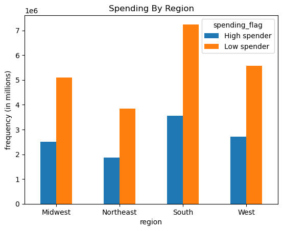

```python
#create bar graph showing spending trends across regions
regional_spending_bar = regional_spending.plot.bar(rot=0)
plt.title('Spending By Region')
plt.ylabel('frequency (in millions)')
```

The most people using instacart live in the South. However, 33% of customers are high spenders regardless of region. This means there is no difference in spending habits across U.S. regions.

```python
path = r'D:\Users\Marlo\OneDrive\OneDrive - South Washington County Schools\Home\job support\Coursework\Achievement 4\Instacart Basket Analysis'
```

```python
#Export regional_spending_bar
regional_spending_bar.figure.savefig(os.path.join(path, '04 Analysis', 'Visualizations', 'regional_spending_bar'))
```

### 4. Create an exclusion flag for low-activity customers

```python
#low-activity customer < 5 orders
ords_prods_cust_clean.loc[ords_prods_cust_clean['max_order']< 5, "customer_activity"] = "Low-Activity Customer"
```

```python
#high-activity customer >= 5 orders
ords_prods_cust_clean.loc[ords_prods_cust_clean['max_order']>= 5, "customer_activity"] = "High-Activity Customer"
```

```python
#check outputs
ords_prods_cust_clean['customer_activity'].value_counts(dropna = False)
```

```
customer_activity
High-Activity Customer    30964564
Low-Activity Customer      1440295
Name: count, dtype: int64
```

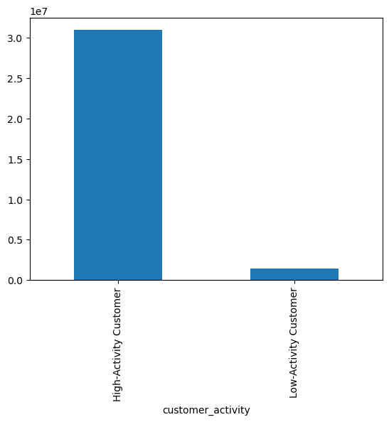

```python
customer_activity_bar = ords_prods_cust_clean['customer_activity'].value_counts().sort_index().plot.bar()
```

95% of customers are high-activity customers.

```python
active_customers = ords_prods_cust_clean[ords_prods_cust_clean['customer_activity'] =='High-Activity Customer']
```

```python
#Check outputs
active_customers.shape
```

```
(30964564, 25)
```

The "active_customers" dataframe has the same number of rows as the "high-activity customers" in the customer_activity chart. Therefore, they should match.

```python
path = r'D:\Users\Marlo\OneDrive\OneDrive - South Washington County Schools\Home\job support\Coursework\Achievement 4\Instacart Basket Analysis'
```

```python
#Export file active_customers
active_customers.to_pickle(os.path.join(path, '02 Data', 'Prepared Data', 'active_customers.pkl'))
```

### 5. Customer Profiling: department, age, income, number of dependants

#### Department

```python
#check outputs of departments column
ords_prods_cust_clean['department_id'].value_counts().sort_index()
```

```
department_id
1     2234743
2       36291
3     1172428
4     9479291
5      153696
6      269253
7     2688123
8       97716
9      866627
10      34573
11     447572
12     708927
13    1875369
14     703033
15    1068058
16    5398747
17     738666
18     423802
19    2887550
20    1051249
21      69145
Name: count, dtype: int64
```

```python
#Show department name instead of id_number
dept_name = pd.read_csv(os.path.join(path, '02 Data', 'Prepared Data', 'departments.csv'))
```

```python
dept_name
```

|  | Unnamed: 0 | department |
| --- | --- | --- |
| 0 | 1 | frozen |
| 1 | 2 | other |
| 2 | 3 | bakery |
| 3 | 4 | produce |
| 4 | 5 | alcohol |
| 5 | 6 | international |
| 6 | 7 | beverages |
| 7 | 8 | pets |
| 8 | 9 | dry goods pasta |
| 9 | 10 | bulk |
| 10 | 11 | personal care |
| 11 | 12 | meat seafood |
| 12 | 13 | pantry |
| 13 | 14 | breakfast |
| 14 | 15 | canned goods |
| 15 | 16 | dairy eggs |
| 16 | 17 | household |
| 17 | 18 | babies |
| 18 | 19 | snacks |
| 19 | 20 | deli |
| 20 | 21 | missing |

```python
#change name of column "Unnamed: 0" to "department_id"
dept_name.rename(columns={'Unnamed: 0' : 'department_id'}, inplace = True)
```

```python
#Merge ords_prods_cust_clean with dept_name
ords_prods_cust_dept = ords_prods_cust_clean.merge(dept_name, on = 'department_id')
```

```python
ords_prods_cust_dept.head()
```

|  | product_id | product_name | department_id | prices | order_id | user_id | order_number | orders_day_of_week | order_hour_of_day | days_since_prior_order | ... | frequency_flag | gender | state | age | number_of_dependants | fam_status | income | region | customer_activity | department |
| --- | --- | --- | --- | --- | --- | --- | --- | --- | --- | --- | --- | --- | --- | --- | --- | --- | --- | --- | --- | --- | --- |
| 0 | 1 | Chocolate Sandwich Cookies | 19 | 5.8 | 3139998 | 138 | 28 | 6 | 11 | 3.0 | ... | frequent customer | Male | Minnesota | 81 | 1 | married | 49620 | Midwest | High-Activity Customer | snacks |
| 1 | 1 | Chocolate Sandwich Cookies | 19 | 5.8 | 1977647 | 138 | 30 | 6 | 17 | 20.0 | ... | frequent customer | Male | Minnesota | 81 | 1 | married | 49620 | Midwest | High-Activity Customer | snacks |
| 2 | 4913 | Table Water Crackers | 19 | 4.4 | 894221 | 138 | 23 | 5 | 13 | 24.0 | ... | frequent customer | Male | Minnesota | 81 | 1 | married | 49620 | Midwest | High-Activity Customer | snacks |
| 3 | 11759 | Organic Simply Naked Pita Chips | 19 | 4.4 | 1986630 | 138 | 7 | 0 | 12 | 7.0 | ... | frequent customer | Male | Minnesota | 81 | 1 | married | 49620 | Midwest | High-Activity Customer | snacks |
| 4 | 13424 | Almonds | 19 | 4.2 | 3139998 | 138 | 28 | 6 | 11 | 3.0 | ... | frequent customer | Male | Minnesota | 81 | 1 | married | 49620 | Midwest | High-Activity Customer | snacks |

5 rows × 26 columns

```python
ords_prods_cust_dept['department'].value_counts()
```

```
department
produce            9479291
dairy eggs         5398747
snacks             2887550
beverages          2688123
frozen             2234743
pantry             1875369
bakery             1172428
canned goods       1068058
deli               1051249
dry goods pasta     866627
household           738666
meat seafood        708927
breakfast           703033
personal care       447572
babies              423802
international       269253
alcohol             153696
pets                 97716
missing              69145
other                36291
bulk                 34573
Name: count, dtype: int64
```

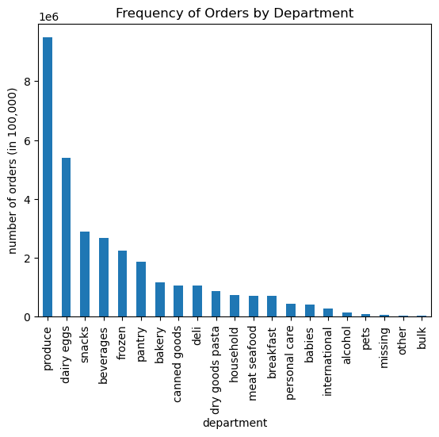

```python
#create bar graph showing frequency of orders in each department
bar_dept_names = ords_prods_cust_dept['department'].value_counts().plot.bar()
plt.title('Frequency of Orders by Department')
plt.ylabel('number of orders (in 100,000)')
```

Produce has the most orders followed by dairy & eggs.

```python
#Export Bar Graph
bar_dept_names.figure.savefig(os.path.join(path, '04 Analysis', 'Visualizations', 'bar_dept_names.png'))
```

#### Age

```python
#Check outputs
ords_prods_cust_dept['age'].value_counts(dropna = False)
```

```
age
49    531360
79    529742
48    529728
31    528551
64    528009
       ...
60    484416
36    483812
66    476219
41    475225
25    472188
Name: count, Length: 64, dtype: int64
```

```python
ords_prods_cust_dept['age'].describe()
```

```
count    3.240486e+07
mean     4.946527e+01
std      1.848558e+01
min      1.800000e+01
25%      3.300000e+01
50%      4.900000e+01
75%      6.500000e+01
max      8.100000e+01
Name: age, dtype: float64
```

```python
#Create age_group flag, young adult <40
ords_prods_cust_dept.loc[ords_prods_cust_dept['age'] <40, "age_group"] = "Young Adult"
```

```python
#Create age_group flag, middle-age >=40, <=60
ords_prods_cust_dept.loc[(ords_prods_cust_dept['age'] >=40) & (ords_prods_cust_dept['age'] <=60), "age_group"] = "Middle-Aged Adult"
```

```python
#Create age_group flag, senior >60
ords_prods_cust_dept.loc[ords_prods_cust_dept['age'] >60, "age_group"] = "Senior"
```

```python
#check outputs
ords_prods_cust_dept['age_group'].value_counts(dropna = False)
```

```
age_group
Young Adult          11164192
Middle-Aged Adult    10657828
Senior               10582839
Name: count, dtype: int64
```

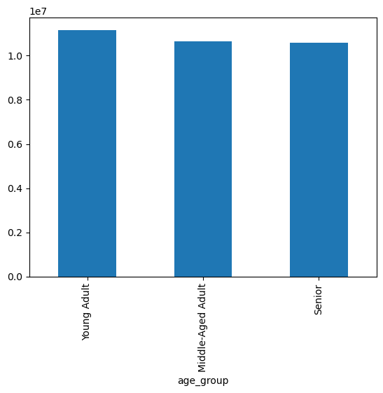

```python
#create bar graph showing age groups
bar_age = ords_prods_cust_dept['age_group'].value_counts().plot.bar()
```

There are about the same number of young adults, middle-aged adults and seniors.

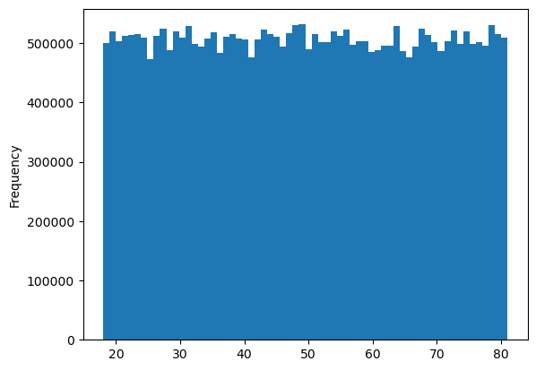

```python
#create histogram showing age of customers
hist_age = ords_prods_cust_dept['age'].plot.hist(bins=64)
```

There are roughly the same amount of people across ages.

#### Income

```python
#Check outputs
ords_prods_cust_dept['income'].describe()
```

```
count    3.240486e+07
mean     9.943773e+04
std      4.305727e+04
min      2.590300e+04
25%      6.700400e+04
50%      9.661800e+04
75%      1.279120e+05
max      5.939010e+05
Name: income, dtype: float64
```

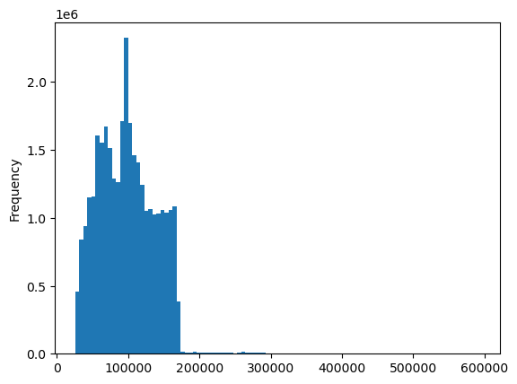

```python
#create histogram showing income of customers
hist_income = ords_prods_cust_dept['income'].plot.hist(bins=100)
```

Most people make under 200,000. The outliers make over 200k.

```python
#Create income_group, low-income <= $67,004
ords_prods_cust_dept.loc[ords_prods_cust_dept['income'] <= 67004, "income_group"] = "Low-Income"
```

```python
#Create income_group flag, mid-income > $67,004, <= $127,912
ords_prods_cust_dept.loc[(ords_prods_cust_dept['income'] > 67004) & (ords_prods_cust_dept['income'] <=127912), "income_group"] = "Mid-Income"
```

```python
#Create income_group, high-income > $127,912
ords_prods_cust_dept.loc[ords_prods_cust_dept['income'] >127912, "income_group"] = "High-Income"
```

```python
#check outputs
ords_prods_cust_dept['income_group'].value_counts(dropna = False)
```

```
income_group
Mid-Income     16202177
Low-Income      8101644
High-Income     8101038
Name: count, dtype: int64
```

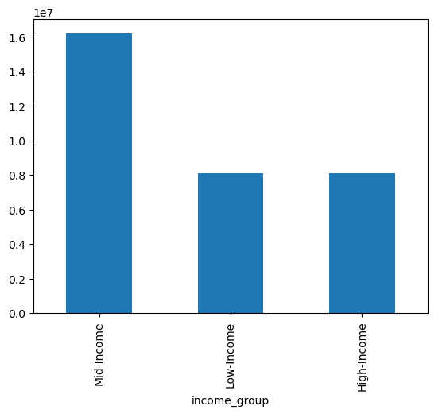

```python
#create bar graph showing income groups
ords_prods_cust_dept['income_group'].value_counts().plot.bar()
```

There are twice as many mid-income level individuals as low-income and high-income.

#### Number of Dependants

```python
#Check outputs
ords_prods_cust_dept['number_of_dependants'].describe()
```

```
count    3.240486e+07
mean     1.501896e+00
std      1.118865e+00
min      0.000000e+00
25%      1.000000e+00
50%      2.000000e+00
75%      3.000000e+00
max      3.000000e+00
Name: number_of_dependants, dtype: float64
```

```python
ords_prods_cust_dept['number_of_dependants'].value_counts()
```

```
number_of_dependants
3    8135109
0    8097503
2    8091143
1    8081104
Name: count, dtype: int64
```

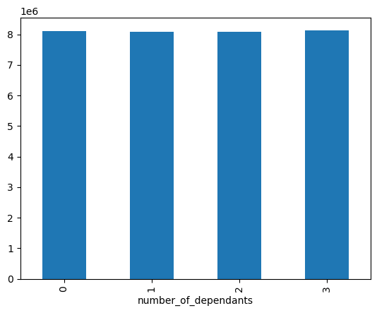

```python
bar_dependants = ords_prods_cust_dept['number_of_dependants'].value_counts().sort_index().plot.bar()
```

There is roughly an equal amount of customers who have 0, 1, 2, and 3 dependants.

```python
#Create dependants groups, no dependants
ords_prods_cust_dept.loc[ords_prods_cust_dept['number_of_dependants']== 0, "dependants_flag"] = 'No Dependants'
```

```python
#Create dependants groups, has dependants
ords_prods_cust_dept.loc[ords_prods_cust_dept['number_of_dependants'] > 0, "dependants_flag"] = 'Has Dependants'
```

```python
#Check outputs
ords_prods_cust_dept['dependants_flag'].value_counts()
```

```
dependants_flag
Has Dependants    24307356
No Dependants      8097503
Name: count, dtype: int64
```

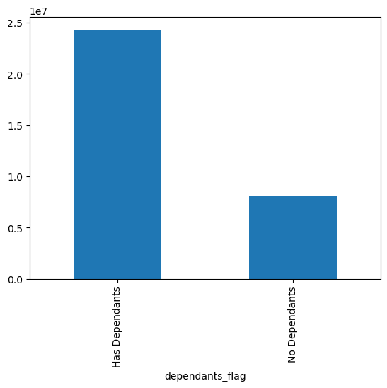

```python
#create bar graph showing customers with dependants
ords_prods_cust_dept['dependants_flag'].value_counts().plot.bar()
```

Customers with dependants make up 75% of the customer population.

#### Creating Customer Portfolios

```python
#Create customer profile: 'High-Income, Senior, Has Dependants'
ords_prods_cust_dept.loc[(ords_prods_cust_dept['income_group'] == 'High-Income') & (ords_prods_cust_dept['age_group'] == 'Senior') & (ords_prods_cust_dept['dependants_flag'] == 'Has Dependants'), 'customer_profile'] = 'High-Income, Senior, Has Dependants'
```

```python
#Create customer profile: 'High-Income, Senior, No Dependants'
ords_prods_cust_dept.loc[(ords_prods_cust_dept['income_group'] == 'High-Income') & (ords_prods_cust_dept['age_group'] == 'Senior') & (ords_prods_cust_dept['dependants_flag'] == 'No Dependants'), 'customer_profile'] = 'High-Income, Senior, No Dependants'
```

```python
#Create customer profile: 'High-Income, Middle-Aged Adult, Has Dependants'
ords_prods_cust_dept.loc[(ords_prods_cust_dept['income_group'] == 'High-Income') & (ords_prods_cust_dept['age_group'] == 'Middle-Aged Adult') & (ords_prods_cust_dept['dependants_flag'] == 'Has Dependants'), 'customer_profile'] = 'High-Income, Middle-Aged Adult, Has Dependants'
```

```python
#Create customer profile: 'High-Income, Middle-Aged Adult, No Dependants'
ords_prods_cust_dept.loc[(ords_prods_cust_dept['income_group'] == 'High-Income') & (ords_prods_cust_dept['age_group'] == 'Middle-Aged Adult') & (ords_prods_cust_dept['dependants_flag'] == 'No Dependants'), 'customer_profile'] = 'High-Income, Middle-Aged Adult, No Dependants'
```

```python
#Create customer profile: 'High-Income, Young Adult, Has Dependants'
ords_prods_cust_dept.loc[(ords_prods_cust_dept['income_group'] == 'High-Income') & (ords_prods_cust_dept['age_group'] == 'Young Adult') & (ords_prods_cust_dept['dependants_flag'] == 'Has Dependants'), 'customer_profile'] = 'High-Income, Young Adult, Has Dependants'
```

```python
#Create customer profile: 'High-Income, Young Adult, No Dependants'
ords_prods_cust_dept.loc[(ords_prods_cust_dept['income_group'] == 'High-Income') & (ords_prods_cust_dept['age_group'] == 'Young Adult') & (ords_prods_cust_dept['dependants_flag'] == 'No Dependants'), 'customer_profile'] = 'High-Income, Young Adult, No Dependants'
```

```python
#Create customer profile: 'Mid-Income, Senior, Has Dependants'
ords_prods_cust_dept.loc[(ords_prods_cust_dept['income_group'] == 'Mid-Income') & (ords_prods_cust_dept['age_group'] == 'Senior') & (ords_prods_cust_dept['dependants_flag'] == 'Has Dependants'), 'customer_profile'] = 'Mid-Income, Senior, Has Dependants'
```

```python
#Create customer profile: 'Mid-Income, Senior, No Dependants'
ords_prods_cust_dept.loc[(ords_prods_cust_dept['income_group'] == 'Mid-Income') & (ords_prods_cust_dept['age_group'] == 'Senior') & (ords_prods_cust_dept['dependants_flag'] == 'No Dependants'), 'customer_profile'] = 'Mid-Income, Senior, No Dependants'
```

```python
#Create customer profile: 'Mid-Income, Middle-Aged Adult, Has Dependants'
ords_prods_cust_dept.loc[(ords_prods_cust_dept['income_group'] == 'Mid-Income') & (ords_prods_cust_dept['age_group'] == 'Middle-Aged Adult') & (ords_prods_cust_dept['dependants_flag'] == 'Has Dependants'), 'customer_profile'] = 'Mid-Income, Middle-Aged Adult, Has Dependants'
```

```python
#Create customer profile: 'Mid-Income, Middle-Aged Adult, No Dependants'
ords_prods_cust_dept.loc[(ords_prods_cust_dept['income_group'] == 'Mid-Income') & (ords_prods_cust_dept['age_group'] == 'Middle-Aged Adult') & (ords_prods_cust_dept['dependants_flag'] == 'No Dependants'), 'customer_profile'] = 'Mid-Income, Middle-Aged Adult, No Dependants'
```

```python
#Create customer profile: 'Mid-Income, Young Adult, Has Dependants'
ords_prods_cust_dept.loc[(ords_prods_cust_dept['income_group'] == 'Mid-Income') & (ords_prods_cust_dept['age_group'] == 'Young Adult') & (ords_prods_cust_dept['dependants_flag'] == 'Has Dependants'), 'customer_profile'] = 'Mid-Income, Young Adult, Has Dependants'
```

```python
#Create customer profile: 'Mid-Income, Young Adult, No Dependants'
ords_prods_cust_dept.loc[(ords_prods_cust_dept['income_group'] == 'Mid-Income') & (ords_prods_cust_dept['age_group'] == 'Young Adult') & (ords_prods_cust_dept['dependants_flag'] == 'No Dependants'), 'customer_profile'] = 'Mid-Income, Young Adult, No Dependants'
```

```python
#Create customer profile: 'Low-Income, Senior, Has Dependants'
ords_prods_cust_dept.loc[(ords_prods_cust_dept['income_group'] == 'Low-Income') & (ords_prods_cust_dept['age_group'] == 'Senior') & (ords_prods_cust_dept['dependants_flag'] == 'Has Dependants'), 'customer_profile'] = 'Low-Income, Senior, Has Dependants'
```

```python
#Create customer profile: 'Low-Income, Senior, No Dependants'
ords_prods_cust_dept.loc[(ords_prods_cust_dept['income_group'] == 'Low-Income') & (ords_prods_cust_dept['age_group'] == 'Senior') & (ords_prods_cust_dept['dependants_flag'] == 'No Dependants'), 'customer_profile'] = 'Low-Income, Senior, No Dependants'
```

```python
#Create customer profile: 'Low-Income, Middle-Aged Adult, Has Dependants'
ords_prods_cust_dept.loc[(ords_prods_cust_dept['income_group'] == 'Low-Income') & (ords_prods_cust_dept['age_group'] == 'Middle-Aged Adult') & (ords_prods_cust_dept['dependants_flag'] == 'Has Dependants'), 'customer_profile'] = 'Low-Income, Middle-Aged Adult, Has Dependants'
```

```python
#Create customer profile: 'Low-Income, Middle-Aged Adult, No Dependants'
ords_prods_cust_dept.loc[(ords_prods_cust_dept['income_group'] == 'Low-Income') & (ords_prods_cust_dept['age_group'] == 'Middle-Aged Adult') & (ords_prods_cust_dept['dependants_flag'] == 'No Dependants'), 'customer_profile'] = 'Low-Income, Middle-Aged Adult, No Dependants'
```

```python
#Create customer profile: 'Low-Income, Young Adult, Has Dependants'
ords_prods_cust_dept.loc[(ords_prods_cust_dept['income_group'] == 'Low-Income') & (ords_prods_cust_dept['age_group'] == 'Young Adult') & (ords_prods_cust_dept['dependants_flag'] == 'Has Dependants'), 'customer_profile'] = 'Low-Income, Young Adult, Has Dependants'
```

```python
#Create customer profile: 'Low-Income, Young Adult, No Dependants'
ords_prods_cust_dept.loc[(ords_prods_cust_dept['income_group'] == 'Low-Income') & (ords_prods_cust_dept['age_group'] == 'Young Adult') & (ords_prods_cust_dept['dependants_flag'] == 'No Dependants'), 'customer_profile'] = 'Low-Income, Young Adult, No Dependants'
```

```python
#check outputs
ords_prods_cust_dept['customer_profile'].value_counts(dropna = False)
```

```
customer_profile
Mid-Income, Young Adult, Has Dependants           4435702
Mid-Income, Middle-Aged Adult, Has Dependants     3890144
Low-Income, Young Adult, Has Dependants           3848804
Mid-Income, Senior, Has Dependants                3834039
High-Income, Senior, Has Dependants               3054244
High-Income, Middle-Aged Adult, Has Dependants    2915584
Mid-Income, Young Adult, No Dependants            1462097
Mid-Income, Senior, No Dependants                 1303231
Low-Income, Young Adult, No Dependants            1291397
Mid-Income, Middle-Aged Adult, No Dependants      1276964
Low-Income, Middle-Aged Adult, Has Dependants     1191018
Low-Income, Senior, Has Dependants                1039965
High-Income, Senior, No Dependants                1012895
High-Income, Middle-Aged Adult, No Dependants      992123
Low-Income, Middle-Aged Adult, No Dependants       391995
Low-Income, Senior, No Dependants                  338465
High-Income, Young Adult, Has Dependants            97856
High-Income, Young Adult, No Dependants             28336
Name: count, dtype: int64
```

### 6. Visualization of Customer Profiles

```python
#Group by customer_profile
customer_profile=ords_prods_cust_dept.groupby(['customer_profile','customer_profile']).size().unstack()
```

```python
#Sort
customer_profile = customer_profile.loc[customer_profile.sum(axis=1).sort_values(ascending = False).index]
```

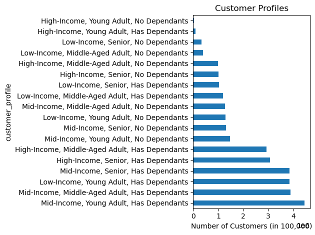

```python
#Create bar graph showing frequency of customer profiles
bar_customer_profile = ords_prods_cust_dept['customer_profile'].value_counts().plot.barh()
plt.title('Customer Profiles')
plt.xlabel('Number of Customers (in 100,000)')
plt.tight_layout()
```

Customers who are mid-income and have dependants are most frequent regardless of age. There is also a high frequency of customers who are low-income young adults with dependants.

There are very few customers who are high-income young adults regardless of whether they have dependants are not. There is also a low frequency of customers who are low-income seniors with no dependants.

```python
#Export bar_customer_profile
bar_customer_profile.figure.savefig(os.path.join(path, '04 Analysis', 'Visualizations', 'bar_customer_profile'))
```

### 7. Aggregate the max, mean, and min variables on a customer-profile level for usage frequency and expenditure.

#### Usage Frequency

```python
#group by 'customer_profile' and find the max, mean, and min of 'days_since_prior_order' for each group
ords_prods_cust_dept.groupby('customer_profile').agg({'days_since_prior_order':['mean', 'min', 'max']})
```

| customer_profile | days_since_prior_order mean | days_since_prior_order min | days_since_prior_order max |
| --- | --- | --- | --- |
| High-Income, Middle-Aged Adult, Has Dependants | 11.147160 | 0.0 | 30.0 |
| High-Income, Middle-Aged Adult, No Dependants | 10.956193 | 0.0 | 30.0 |
| High-Income, Senior, Has Dependants | 10.975388 | 0.0 | 30.0 |
| High-Income, Senior, No Dependants | 10.952417 | 0.0 | 30.0 |
| High-Income, Young Adult, Has Dependants | 10.460443 | 0.0 | 30.0 |
| High-Income, Young Adult, No Dependants | 10.169317 | 0.0 | 30.0 |
| Low-Income, Middle-Aged Adult, Has Dependants | 11.541423 | 0.0 | 30.0 |
| Low-Income, Middle-Aged Adult, No Dependants | 11.194385 | 0.0 | 30.0 |
| Low-Income, Senior, Has Dependants | 11.604793 | 0.0 | 30.0 |
| Low-Income, Senior, No Dependants | 11.665194 | 0.0 | 30.0 |
| Low-Income, Young Adult, Has Dependants | 11.181082 | 0.0 | 30.0 |
| Low-Income, Young Adult, No Dependants | 11.268781 | 0.0 | 30.0 |
| Mid-Income, Middle-Aged Adult, Has Dependants | 11.040493 | 0.0 | 30.0 |
| Mid-Income, Middle-Aged Adult, No Dependants | 11.020042 | 0.0 | 30.0 |
| Mid-Income, Senior, Has Dependants | 11.059597 | 0.0 | 30.0 |
| Mid-Income, Senior, No Dependants | 10.946836 | 0.0 | 30.0 |
| Mid-Income, Young Adult, Has Dependants | 11.016372 | 0.0 | 30.0 |
| Mid-Income, Young Adult, No Dependants | 11.115545 | 0.0 | 30.0 |

#### Expenditure

```python
#group by 'customer_profile' and find the max, mean, and min of 'prices' for each group
ords_prods_cust_dept.groupby('customer_profile').agg({'prices':['mean', 'min', 'max']})
```

| customer_profile | prices mean | prices min | prices max |
| --- | --- | --- | --- |
| High-Income, Middle-Aged Adult, Has Dependants | 7.960246 | 1.0 | 25.0 |
| High-Income, Middle-Aged Adult, No Dependants | 7.946934 | 1.0 | 25.0 |
| High-Income, Senior, Has Dependants | 7.962753 | 1.0 | 25.0 |
| High-Income, Senior, No Dependants | 7.943874 | 1.0 | 25.0 |
| High-Income, Young Adult, Has Dependants | 7.765332 | 1.0 | 25.0 |
| High-Income, Young Adult, No Dependants | 7.714424 | 1.0 | 25.0 |
| Low-Income, Middle-Aged Adult, Has Dependants | 6.812219 | 1.0 | 25.0 |
| Low-Income, Middle-Aged Adult, No Dependants | 6.808606 | 1.0 | 25.0 |
| Low-Income, Senior, Has Dependants | 6.695146 | 1.0 | 25.0 |
| Low-Income, Senior, No Dependants | 6.699276 | 1.0 | 25.0 |
| Low-Income, Young Adult, Has Dependants | 7.588515 | 1.0 | 25.0 |
| Low-Income, Young Adult, No Dependants | 7.584603 | 1.0 | 25.0 |
| Mid-Income, Middle-Aged Adult, Has Dependants | 7.962808 | 1.0 | 25.0 |
| Mid-Income, Middle-Aged Adult, No Dependants | 7.971914 | 1.0 | 25.0 |
| Mid-Income, Senior, Has Dependants | 7.957966 | 1.0 | 25.0 |
| Mid-Income, Senior, No Dependants | 7.970154 | 1.0 | 25.0 |
| Mid-Income, Young Adult, Has Dependants | 7.959742 | 1.0 | 25.0 |
| Mid-Income, Young Adult, No Dependants | 7.951665 | 1.0 | 25.0 |

#### Group by Age

```python
#group by 'age_group' and find the max, mean, and min of 'days_since_prior_order' & price for each group
age_group_agg = ords_prods_cust_dept.groupby('age_group')[['days_since_prior_order','prices']].agg(['mean', 'min', 'max'])
```

```python
age_group_agg
```

| age_group | days_since_prior_order mean | days_since_prior_order min | days_since_prior_order max | prices mean | prices min | prices max |
| --- | --- | --- | --- | --- | --- | --- |
| Middle-Aged Adult | 11.120555 | 0.0 | 30.0 | 7.790690 | 1.0 | 25.0 |
| Senior | 11.083299 | 0.0 | 30.0 | 7.795148 | 1.0 | 25.0 |
| Young Adult | 11.108046 | 0.0 | 30.0 | 7.784985 | 1.0 | 25.0 |

#### Group by Income

```python
#group by 'income_group' and find the max, mean, and min of 'days_since_prior_order' & price for each group
income_group_agg = ords_prods_cust_dept.groupby('income_group')[['days_since_prior_order','prices']].agg(['mean', 'min', 'max'])
```

```python
income_group_agg
```

| income_group | days_since_prior_order mean | days_since_prior_order min | days_since_prior_order max | prices mean | prices min | prices max |
| --- | --- | --- | --- | --- | --- | --- |
| High-Income | 11.022757 | 0.0 | 30.0 | 7.954299 | 1.0 | 25.0 |
| Low-Income | 11.322700 | 0.0 | 30.0 | 7.284206 | 1.0 | 25.0 |
| Mid-Income | 11.036036 | 0.0 | 30.0 | 7.961126 | 1.0 | 25.0 |

#### Group by Dependants

```python
#group by 'dependants_flag' and find the max, mean, and min of 'days_since_prior_order' & price for each group
dependants_flag_agg = ords_prods_cust_dept.groupby('dependants_flag')[['days_since_prior_order','prices']].agg(['mean', 'min', 'max'])
```

```python
dependants_flag_agg
```

| dependants_flag | days_since_prior_order mean | days_since_prior_order min | days_since_prior_order max | prices mean | prices min | prices max |
| --- | --- | --- | --- | --- | --- | --- |
| Has Dependants | 11.111834 | 0.0 | 30.0 | 7.790498 | 1.0 | 25.0 |
| No Dependants | 11.080805 | 0.0 | 30.0 | 7.789227 | 1.0 | 25.0 |

### 8. Compare Customer Profiles with Regions and Departments

```python
#Check outputs
ords_prods_cust_dept.info()
```

```
<class 'pandas.core.frame.DataFrame'>
RangeIndex: 32404859 entries, 0 to 32404858
Data columns (total 30 columns):
 #   Column                         Dtype
---  ------                         -----
 0   product_id                     int64
 1   product_name                   object
 2   department_id                  int64
 3   prices                         float64
 4   order_id                       int64
 5   user_id                        object
 6   order_number                   int64
 7   orders_day_of_week             int64
 8   order_hour_of_day              int64
 9   days_since_prior_order         float64
```

[output cut: 22 more lines]

#### Group by Region

##### Customer Profile

```python
#Group by customer profile and region
profile_region=ords_prods_cust_dept.groupby(['customer_profile','region']).size().unstack()
```

```python
#Sort
profile_region = profile_region.loc[profile_region.sum(axis=1).sort_values(ascending = True).index]
```

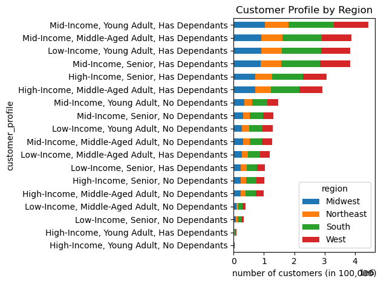

```python
#create bar graph
bar_profile_region = profile_region.plot.barh(stacked = True, title = 'Customer Profile by Region', xlabel = 'number of customers (in 100,000)')
plt.tight_layout()
```

The demographic information suggests classifications in the areas of income, age, and dependants. Combining these together creates 18 different customer profiles.

Mid-Income, Young Adults with Dependants are the largest group among customers. The largest customer profiles all have dependents. Mid-Income makes up 3/5 of the top customer profiles.

Across all customers profiles, the proportions of customers are the same. This means there are no regional differences in customer income, age, and number of dependants.

```python
#Export profile_region
bar_profile_region.figure.savefig(os.path.join(path, '04 Analysis', 'Visualizations', 'bar_profile_region'))
```

##### Age

```python
#Group by age_group and region
age_region=ords_prods_cust_dept.groupby(['age_group','region']).size().unstack()
```

```python
#Sort
age_region = age_region.loc[age_region.sum(axis=1).sort_values(ascending = True).index]
```

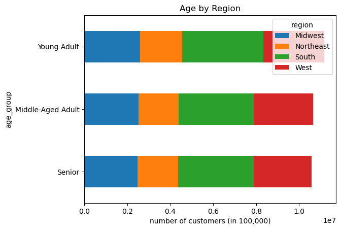

```python
#create bar graph
bar_age_region = age_region.plot.barh(stacked = True, title = 'Age by Region', xlabel = 'number of customers (in 100,000)')
```

There is roughly the same number of customers in each region for each age group.

```python
#Export bar_age_region
bar_age_region.figure.savefig(os.path.join(path, '04 Analysis', 'Visualizations', 'bar_age_region'))
```

```python
#aggregating 'order_id' and 'prices' from sample
age_revenue = ords_prods_cust_dept.groupby(['department', 'fam_status','region'], as_index=False).agg({'order_id': 'count', 'prices': 'sum'})
age_revenue.head(3)
```

|  | department | fam_status | region | order_id | prices |
| --- | --- | --- | --- | --- | --- |
| 0 | alcohol | divorced/widowed | Midwest | 3280 | 27221.1 |
| 1 | alcohol | divorced/widowed | Northeast | 1902 | 15213.9 |
| 2 | alcohol | divorced/widowed | South | 4326 | 33255.3 |

###### Income

```python
#Group by income_group and region
income_region=ords_prods_cust_dept.groupby(['income_group', 'region']).size().unstack()
```

```python
#Sort
income_region = income_region.loc[income_region.sum(axis=1).sort_values(ascending = True).index]
```

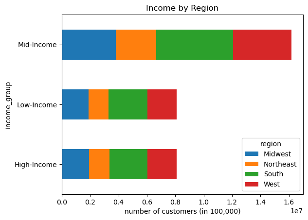

```python
#create bar graph
bar_income_region = income_region.plot.barh(stacked = True, title = 'Income by Region', xlabel = 'number of customers (in 100,000)')
```

There is roughly the same proportion of customers in each region for each income group.

##### Dependants

```python
#Group by dependants_flag and region
dependants_region=ords_prods_cust_dept.groupby(['dependants_flag', 'region']).size().unstack()
```

```python
#Sort
dependants_region = dependants_region.loc[dependants_region.sum(axis=1).sort_values(ascending = True).index]
```

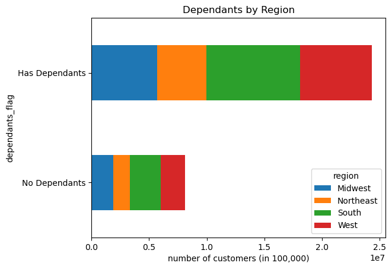

```python
#create bar graph
bar_dependants_region = dependants_region.plot.barh(stacked = True, title = 'Dependants by Region', xlabel = 'number of customers (in 100,000)')
```

There is roughly the same proportion of customers in each region for dependants vs. no dependants.

#### Group by Department

##### Customer Profile

```python
#Group by customer profile and department
profile_department=ords_prods_cust_dept.groupby(['customer_profile','department']).size().unstack()
```

```python
#Sort
profile_department = profile_department.loc[profile_department.sum(axis=1).sort_values(ascending = True).index]
```

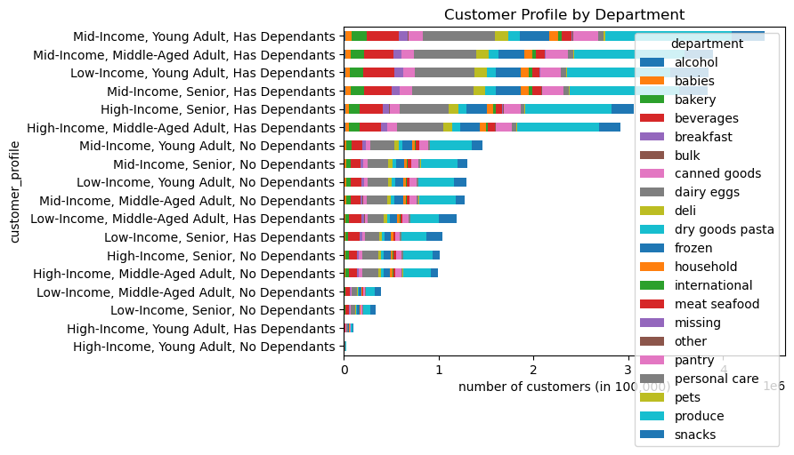

```python
#create bar graph
bar_profile_department = profile_department.plot.barh(stacked = True, title = 'Customer Profile by Department', xlabel = 'number of customers (in 100,000)')
```

Across all customer profiles, produce is the most popular department, followed by dairy/eggs.

There is not a significant difference between income, age, and dependants groups.

##### Age

```python
#Group by age and department
age_department=ords_prods_cust_dept.groupby(['age_group','department']).size().unstack()
```

```python
#Sort
age_department = age_department.loc[age_department.sum(axis=1).sort_values(ascending = True).index]
```

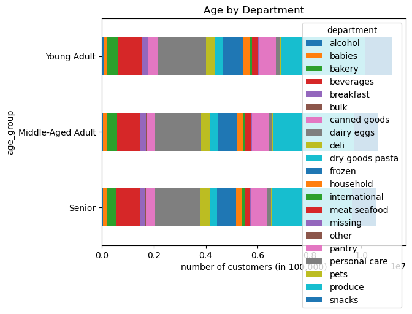

```python
#create bar graph
bar_age_department = age_department.plot.barh(stacked = True, title = 'Age by Department', xlabel = 'number of customers (in 100,000)')
```

There is roughly the same proportion of department sales across age groups. This shows age is not a determining factor in department sales.

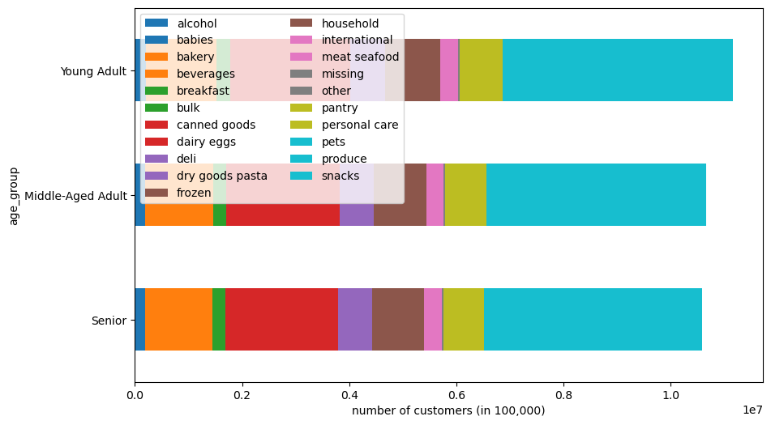

```python
#create 100% stacked bar graph
age_department.plot(kind='barh',
                    stacked=True,
                    colormap='tab10',
                    figsize=(10, 6))

plt.legend(loc="upper left", ncol=2)
plt.xlabel("number of customers (in 100,000)")
plt.ylabel("age_group")
plt.show()
```

There is roughly the same proportion of department sales across age groups. This shows age is not a determining factor in department sales.

##### Income

```python
#Group by income and department
income_department=ords_prods_cust_dept.groupby(['income_group','department']).size().unstack()
```

```python
#Sort
income_department = income_department.loc[income_department.sum(axis=1).sort_values(ascending = True).index]
```

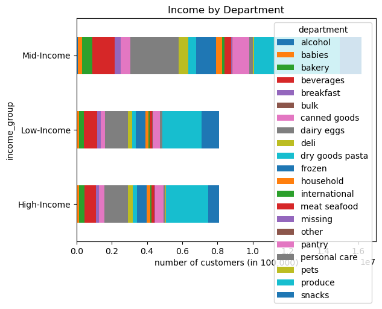

```python
#create bar graph
bar_income_department = income_department.plot.barh(stacked = True, title = 'Income by Department', xlabel = 'number of customers (in 100,000)')
```

There is roughly the same proportion of department sales across income groups. This shows income is not a determining factor in department sales.

##### Dependants

```python
#Group by dependants and department
dependants_department=ords_prods_cust_dept.groupby(['dependants_flag','department']).size().unstack()
```

```python
#Sort
dependants_department = dependants_department.loc[dependants_department.sum(axis=1).sort_values(ascending = True).index]
```

[figure not shown]

```python
#create bar graph
bar_dependants_department = dependants_department.plot.barh(stacked = True, title = 'Dependants by Department', xlabel = 'number of customers (in 100,000)')
```

There is roughly the same proportion of department sales across dependants groups. This shows number of dependants is not a determining factor in department sales.

### 9. Export data set

```python
#Export ords_prods_cust_dept file
ords_prods_cust_dept.to_pickle(os.path.join(path, '02 Data', 'Prepared Data', 'ords_prods_cust_dept.pkl'))
```